# 05.Example 1

Modified

Su 2026-09-13 19:38

## Given:

A very long rod $5\ \mathrm{mm}$ in diameter has one end maintained at $100\ \mathrm{°C}$. The surface of the rod is exposed to ambient air at $25\ \mathrm{°C}$ with a convection heat transfer coefficient of $100\ \frac{\mathrm{W}}{\left(\mathrm{K} \cdot \mathrm{m}^{2}\right)}$.

## Required:

1. Determine the temperature distributions along rods constructed from pure copper, 2024 aluminum alloy, and type AISI 316 stainless steel. What are the corresponding heat losses from the rods?
2. Estimate how long the rods must be for the assumption of infinite length to yield an accurate estimate of the heat loss.

## Solution:

Start first by importing any needed libraries and defining the unit registry.

```python
import matplotlib.pyplot as plt
import numpy as np
import pint

ureg = pint.UnitRegistry()
```

Next, define all of the given values.

$$D = 5\ \mathrm{mm}$$
$$T_b = 100\ \mathrm{°C} = 373.15\ \mathrm{K}$$
$$T_\infty = 25\ \mathrm{°C} = 298.15\ \mathrm{K}$$
$$h = 100\ \frac{\mathrm{W}}{\left(\mathrm{K} \cdot \mathrm{m}^{2}\right)}$$

The material properties will be evaluated at the average temperature of $T_b$ and $T_\infty$. So

$$\bar{T} = \frac{T_b+T_\infty}{2} = 335.6\ \mathrm{K} = 62.5\ \mathrm{°C}$$

Going to table A.1 for copper, aluminum, and stainless steel at $\bar{T}$ shows that interpolation is needed. This is shown below.

$$T_A = 200\ \mathrm{K}$$
$$T_B = 400\ \mathrm{K}$$
$$k_A = 413\ \frac{\mathrm{W}}{\left(\mathrm{K} \cdot \mathrm{m}\right)}$$
$$k_B = 393\ \frac{\mathrm{W}}{\left(\mathrm{K} \cdot \mathrm{m}\right)}$$
$$k_{cu} = (\frac{\bar{T}-T_A}{T_B-T_A}) (k_B-k_A) + k_A = 399.4\ \frac{\mathrm{W}}{\left(\mathrm{K} \cdot \mathrm{m}\right)}$$

$$T_A = 200\ \mathrm{K}$$
$$T_B = 400\ \mathrm{K}$$
$$k_A = 163\ \frac{\mathrm{W}}{\left(\mathrm{K} \cdot \mathrm{m}\right)}$$
$$k_B = 186\ \frac{\mathrm{W}}{\left(\mathrm{K} \cdot \mathrm{m}\right)}$$
$$k_{al} = (\frac{\bar{T}-T_A}{T_B-T_A}) (k_B-k_A) + k_A = 178.6\ \frac{\mathrm{W}}{\left(\mathrm{K} \cdot \mathrm{m}\right)}$$

$$T_A = 300\ \mathrm{K}$$
$$T_B = 400\ \mathrm{K}$$
$$k_A = 13.4\ \frac{\mathrm{W}}{\left(\mathrm{K} \cdot \mathrm{m}\right)}$$
$$k_B = 15.2\ \frac{\mathrm{W}}{\left(\mathrm{K} \cdot \mathrm{m}\right)}$$
$$k_{ss} = (\frac{\bar{T}-T_A}{T_B-T_A}) (k_B-k_A) + k_A = 14.0\ \frac{\mathrm{W}}{\left(\mathrm{K} \cdot \mathrm{m}\right)}$$

Going to the tip conditions table found in the notes shows that the temperature distribution function for an infinite long fin is

$$\theta = \theta_b e^{-mx}$$

Or this may be expressed in terms of temperature as

$$T = \left(T_b-T_\infty \right) e^{-mx}+T_\infty$$

where $m$ is

$$m=\sqrt{\frac{hP}{k A_c}}$$

For a round fin with a constant cross sectional area, the $P$ and $A_c$ terms may be expressed as

$$P = \pi D = 15.7\ \mathrm{mm}$$
$$A_c = \frac{\pi}{4} D^2 = 19.6\ \mathrm{mm}^{2}$$

For the different materials, the $m$ term is

$$m_{cu} = \sqrt{\frac{h P}{k_{cu} A_c}} = 14.15\ \frac{1}{\mathrm{m}}$$

$$m_{al} = \sqrt{\frac{h P}{k_{al} A_c}} = 21.16\ \frac{1}{\mathrm{m}}$$

$$m_{ss} = \sqrt{\frac{h P}{k_{ss} A_c}} = 75.48\ \frac{1}{\mathrm{m}}$$

To plot the temperature distribution, a Python function may be used. This is shown below.

```python
def Tdist(x, m):
    return (T_b - T_inf)*math.e**(-m*x) + T_inf
```

The $x$ values for the plot may now be created using a [Numpy array](https://numpy.org/doc/stable/reference/generated/numpy.linspace.html) ranging from $0mm$ to $350mm$. This is shown below.

```python
x = np.linspace(0, 350)*ureg.mm
```

The temperature values may now be found using the temperature distribution function `Tdist`. This is shown below.

```python
T_cu = Tdist(x, m_cu)
T_al = Tdist(x, m_al)
T_ss = Tdist(x, m_ss)
```

The plot may now be built. This is shown below.

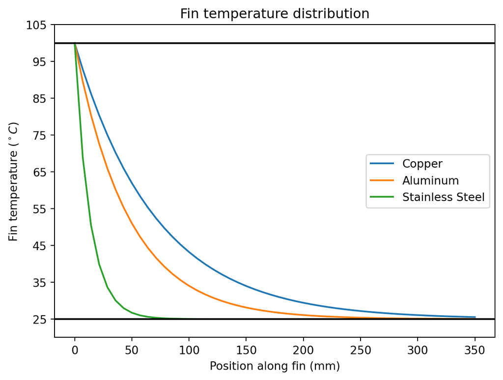

```python
fig, ax = plt.subplots(1, 1)

ax.plot(x.to('mm').magnitude, T_cu.to('degC').magnitude, label = 'Copper')
ax.plot(x.to('mm').magnitude, T_al.to('degC').magnitude, label = 'Aluminum')
ax.plot(x.to('mm').magnitude, T_ss.to('degC').magnitude, label = 'Stainless Steel')

ax.set_xlabel('Position along fin (mm)')
ax.set_ylabel('Fin temperature ($^\\circ C$)')
ax.set_title('Fin temperature distribution')

ax.axhline(y = T_b.to('degC').magnitude, color = 'k')
ax.axhline(y = T_inf.to('degC').magnitude, color = 'k')

ax.set_ylim([20, 105])
ax.set_yticks(range(25, 110, 10))

ax.legend()
plt.show()
```

The heat loss from the fin the is given by

$$q_f=\sqrt{hPkA_c}\theta_b=\sqrt{h\left(\pi D\right)k\left(\frac{\pi}{4} D^2\right)}\theta_b=\sqrt{\frac{\pi^2 h k D^3}{4}}\theta_b$$

For the different materials, this becomes

Answer (a1): $q_{cu} = \sqrt{\frac{\pi^2 h k_{cu} D^3}{4}}(T_b - T_{\infty}) = 8.32\ \mathrm{W}$

Answer (a2): $q_{al} = \sqrt{\frac{\pi^2 h k_{al} D^3}{4}}(T_b - T_{\infty}) = 5.57\ \mathrm{W}$

Answer (a2): $q_{ss} = \sqrt{\frac{\pi^2 h k_{ss} D^3}{4}}(T_b - T_{\infty}) = 1.56\ \mathrm{W}$

To find the required length of fin for it to be considered infinitely long, we must first realize that an infinitely long fin will have adiabatic condition at the tip. Referring to the tip conditions table, it shows that the heat loss from the fin for the adiabatic tip is

$$q_f=\sqrt{hPkA_c}\tanh m L$$

Comparing this to the heat loss from the fin for the infinitely long fin, it may be seen that the difference is the hyperbolic tangent function. Thus, for the two cases to be the same, the hyperbolic tangent function must be equal to $1$. The hyperbolic tangent function is never $1$, though. However, it gets infinitely close to $1$. We may approximate this by saying the hyperbolic tangent function is $0.99$. That is

$$\tanh m L = 0.99$$

Thus, when the $mL$ term is

$$m L = \tanh^{-1}(0.99) \approx 2.647$$

the rod may be considered infinitely long. Solving for $L$ shows

$$L_\infty=\frac{\tanh^{-1}\left(0.99\right)}{\sqrt{\frac{hP}{kA_c}}}$$

This may be found for the different materials. This is shown below.

Answer (b1): $L_{cu} = \frac{\tanh^{-1}(0.99)}{\sqrt{\frac{hP}{k_{cu} A_c}}} = 187.0\ \mathrm{mm}$

Answer (b2): $L_{al} = \frac{\tanh^{-1}(0.99)}{\sqrt{\frac{hP}{k_{al} A_c}}} = 125.1\ \mathrm{mm}$

Answer (b3): $L_{ss} = \frac{\tanh^{-1}(0.99)}{\sqrt{\frac{hP}{k_{ss} A_c}}} = 35.1\ \mathrm{mm}$